# Funciones de probabilidad para Diseño de Experimentos

# Distribución t de Student

Función de densidad:

$f(t_{n})=\frac{1}{\sqrt{n\pi}} \frac{\Gamma (\frac{n+1}{n})}{\Gamma \frac{n}{2}} \frac{1}{(1+\frac{t^{2}}{n})^{\frac{n+1}{n}}}$

## 28. Determina los valores de las siguientes cantidades

### 28 (a) Por tablas $t_{\alpha, \nu}$

$P(T>t_{\alpha, \nu})=\int_{\alpha, \nu}^{\infty} f(t) dt$

1. $t_{0.1,15}$=$\int_{0.1,15}^{\infty} f(t) dt$=1.341
2. $t_{0.05,15}$=$\int_{0.05,15}^{\infty} f(t)dt$=1.753
3. $t_{0.05,25}$=$\int_{0.05,25}^{\infty} f(t)dt$=1.708
4. $t_{0.05,40}$=$\int_{0.05,40}^{\infty} f(t)dt$=1.684
5. $t_{0.005,40}$=$\int_{0.005,40}^{\infty} f(t)dt$=2.704

Tablas:

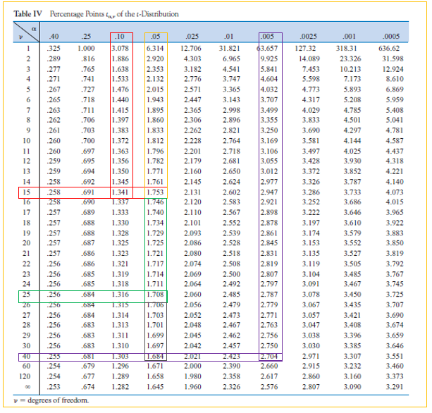

```r
 knitr::include_graphics("tab2.png")
```

### 28 (b) Con R

Valores estadisticos para los cuales la probabilidad a la derecha es $\alpha$

1. $t_{0.1,15}$=$\int_{0.1,15}^{\infty} f(t) dt$

```r
qt(0.1,15,lower.tail = FALSE)
```

```
## [1] 1.340606
```

2. $t_{0.05,15}$=$\int_{0.05,15}^{\infty} f(t)dt$

```r
qt(0.05,15,lower.tail = FALSE)
```

```
## [1] 1.75305
```

3. $t_{0.05,25}$=$\int_{0.05,25}^{\infty} f(t)dt$

```r
qt(0.05,25,lower.tail = FALSE)
```

```
## [1] 1.708141
```

4. $t_{0.05,40}$=$\int_{0.05,40}^{\infty} f(t)dt$

```r
qt(0.05,40,lower.tail = FALSE)
```

```
## [1] 1.683851
```

5. $t_{0.005,40}$=$\int_{0.005,40}^{\infty} f(t)dt$

```r
qt(0.005,40,lower.tail = FALSE)
```

```
## [1] 2.704459
```

## 29. Determina el valor critico *t* para los siguientes casos:

### 29(a) Por tablas

1. Central area=0.95, df=10

Observación: $1-\alpha=1-0.95=0.05$ => $\alpha=0.05/2=0.025$

=> $t_{0.025,10}$=2.228

2. Central area=0.95, df=20

Observación: $1-\alpha=1-0.95=0.05$ => $\alpha=0.05/2=0.025$

=> $t_{0.025,20}$=2.086

3. Central area=0.99, df=20

Observación: $1-\alpha=1-0.99=0.01$ => $\alpha=0.01/2=0.005$

=> $t_{0.005,20}$=2.845

4. Central area=0.99, df=50

Observación: $1-\alpha=1-0.99=0.01$ => $\alpha=0.01/2=0.005$

=> $t_{0.005,50}$=2.682 (este valor se obtuvo interpolando, ver figura)

5. Upper-tail area=0.01, df=25

Observación: $\alpha=0.01$

=> $t_{0.01,25}$=2.485

6. Lower-tail area=0.025, df=5

Observación: $\alpha=0.025$

=> $t_{0.025,5}$=-2.571

Tablas:

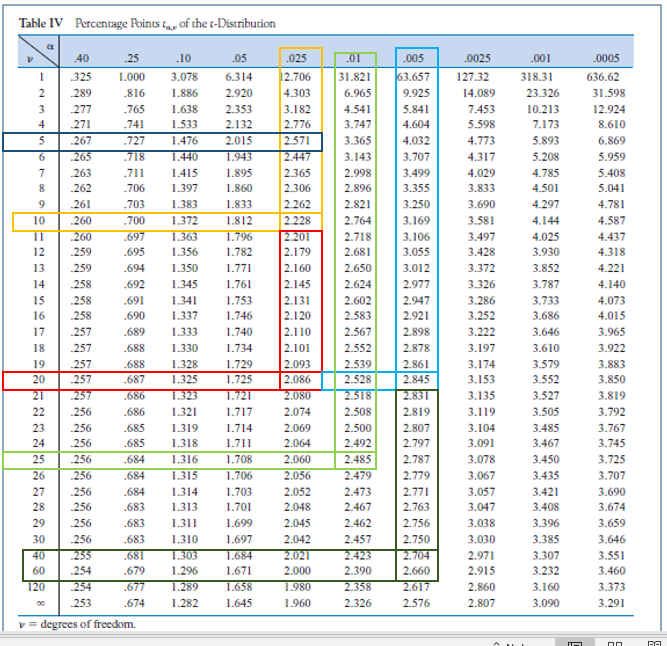

```r
 knitr::include_graphics("tab3.png")
```

### 2.29 (b) Con R.

Para corroborar los resultados anteriores se debe cumplir $t_{\alpha, \nu}=$ central área.

1. $t_{0.025,10}$=$\int_{0.025,10}^{\infty} f(t)dt$

```r
qt(0.975,10)
```

```
## [1] 2.228139
```

2. $t_{0.025,20}$=$\int_{0.025,20}^{\infty} f(t)dt$

```r
qt(0.975,20)
```

```
## [1] 2.085963
```

3. $t_{0.995,20}$=$\int_{0.995,10}^{\infty} f(t)dt$

```r
qt(0.995,20)
```

```
## [1] 2.84534
```

4. $t_{0.995,50}$=$\int_{0.995,50}^{\infty} f(t)dt$

```r
qt(0.995,50)
```

```
## [1] 2.677793
```

```r
qt(0.01,25,lower.tail = FALSE)
```

```
## [1] 2.485107
```

$t_{0.025,5}$=$\int_{0.025,5}^{\infty} f(t)dt$

```r
qt(0.025,5)
```

```
## [1] -2.570582
```

# Distribución $X^{2}$ de Pearson

La distribución que sigue la v.a. *X* se le denomina *Distribución $X^{2}$ de Pearson con n grados de libertad y se denota:

X-> $X^{2}$ con función de densidad:

$f(x)=\frac{1}{2^{\frac{n}{2}} \Gamma (\frac{n}{2})}e^{\frac{-x}{2}}x^{(\frac{n}{2})-1}$

## 42. Determine los valores de las siguientes cantidades $X^{2}_{\alpha,\nu}$

$P[X_n^2>X_{\alpha,\nu}^2]$=$\int_{X_{\alpha,\nu}^2}^{\infty}f(x)dx$

### 42 (a) Por tablas

Tablas:

[figure not shown]

```r
 knitr::include_graphics("tab3.png")
```

### 42 (b) Evaluando con R

1. $X^{2}_{0.1,15}$=$\int_{X_{0.1,15}^2}^{\infty}f(x)dx$=

```r
qchisq(0.1,15,lower.tail = FALSE)
```

```
## [1] 22.30713
```

2. $X^{2}_{0.1,25}$=$\int_{X_{0.1,25}^2}^{\infty}f(x)dx$=

```r
qchisq(0.1,25,lower.tail = FALSE)
```

```
## [1] 34.38159
```

3. $X^{2}_{0.01,25}$= $\int_{X_{0.01,25}^2}^{\infty}f(x)dx$=

```r
qchisq(0.01,25,lower.tail = FALSE)
```

```
## [1] 44.3141
```

4. $X^{2}_{0.005,25}$=$\int_{X_{0.005,25}^2}^{\infty}f(x)dx$

```r
qchisq(0.005,25,lower.tail = FALSE)
```

```
## [1] 46.92789
```

5. $X^{2}_{0.99,25}$=$\int_{X_{0.99,25}^2}^{\infty}f(x)dx$

```r
qchisq(0.99,25,lower.tail = FALSE)
```

```
## [1] 11.52398
```

6. $X^{2}_{0.995,25}$=$\int_{X_{0.995,25}^2}^{\infty}f(x)dx$=

```r
qchisq(0.995,25,lower.tail = FALSE)
```

```
## [1] 10.51965
```

## 43. Determine lo siguiente

### 43 (a) Por Tablas P[$X^{2}>=P$]

1. El 95 percentil de la distribución ji cuadrada con $\nu=10$= 18.3

$X^{2}_{0.95,10}$=$\int_{X_{0.95,10}^2}^{\infty}f(x)dx$

2. El 5 percentil de la distribución ji cuadrada con $\nu=10$= 3.94

$X^{2}_{0.05,10}$=$\int_{X_{0.05,10}^2}^{\infty}f(x)dx$

3. P($10.98 <= X^2 <= 36.78$), donde $X^2$ es una variable aleatoria ji cuadrada con $\nu=22$

=> P($10.98 <= X^2 <= 36.78$)=P(X^2 <= 36.78$)-P($X^2 <= 10.98)=0.975-0.025=0.95

4. P($X^2<14.611$ o $X^2>37.652$), $\nu=25$= P($X^2<14.611$) + P($X^2>37.652$)=0.05+0.05=0.1

Tablas

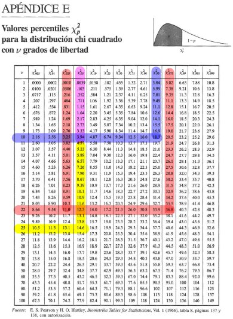

```r
 knitr::include_graphics("tab5.png")
```

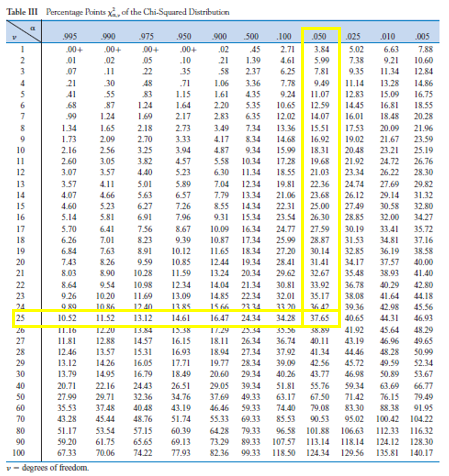

```r
 knitr::include_graphics("tab6.png")
```

### 43 (b) Cálculo con R

1. El 95 percentil de la distribución ji cuadrada con $\nu=10$= 18.3

$X^{2}_{0.95,10}$=$\int_{X_{0.95,10}^2}^{\infty}f(x)dx$

```r
qchisq(0.95,10)
```

```
## [1] 18.30704
```

2. El 5 percentil de la distribución ji cuadrada con $\nu=10$= 3.94

$X^{2}_{0.05,10}$=$\int_{X_{0.05,10}^2}^{\infty}f(x)dx$

```r
qchisq(0.05,10)
```

```
## [1] 3.940299
```

```r
pchisq(36.78,22)-pchisq(10.98,22)
```

```
## [1] 0.9500284
```

```r
pchisq(14.611,25)+pchisq(37.652,25, lower.tail = FALSE)
```

```
## [1] 0.09999683
```

# Distribución F de Snedecor

Se define la variable aleatoria F-Snedecor como el cociente:

$F=\frac{\frac{X_1}{n_1}}{\frac{X_2}{n_2}}$

Donde, $X_1$,$X_2$ son dos variables aleatorias independientes entre sí. Además, F se distribuye según una F-Snedecor con $n_1$ y $n_2$ grados de libertad.

## 57. Obtener las siguientes cantidades** $F_{\alpha,n_1,n_2}$

### 57 (a) Por tablas**

Tabla

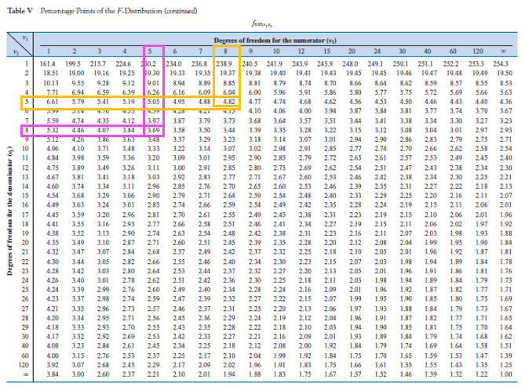

```r
 knitr::include_graphics("tabF1.png")
```

5. El 99 percentil de F con $\nu_{1}$=10 y $\nu_{2}=12$

=>$F_{0.01,10,12}$=4.30

Tabla

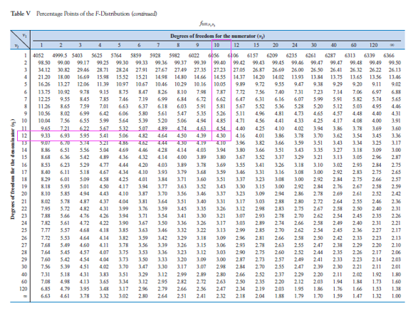

```r
 knitr::include_graphics("tabF2.png")
```

7. P(F>6.16), $\nu_{1}$=6 y $\nu_{4}$ Se busca en las tablas la que tenga en la intersección de los valoes 6 y 4 el resultado de 6.16

Corresponde a $f=0.05$, es decir: $f_{0.05,6,4}=6.16

Tabla

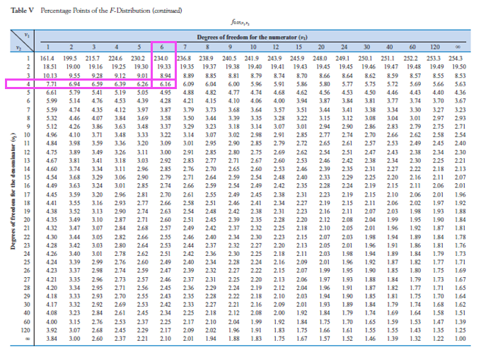

```r
 knitr::include_graphics("tabF3.png")
```

8. P($0.177<F<4.74$) para $\nu_{1}$=10 y $\nu_{2}=5$

=>Se busca en las tablas la que en la intersección entre de $\nu_{1}$=10 y $\nu_{2}=5$ de 0.177 y 4.74

Tabla

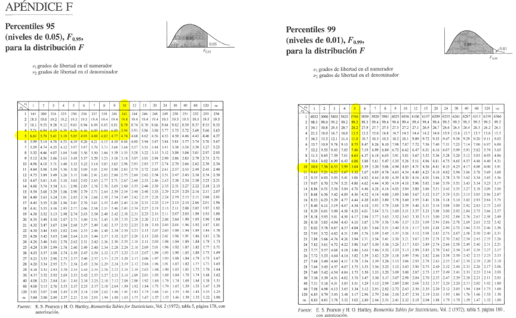

```r
 knitr::include_graphics("tabF4.png")
```

**57 (b) Con R**

1. $F_{0.05,5,8}$= 3.69

```r
qf(0.05,5,8,lower.tail = FALSE)
```

```
## [1] 3.687499
```

2. $F_{0.05,8,5}$= 4.82

```r
qf(0.05,8,5,lower.tail = FALSE)
```

```
## [1] 4.81832
```

3. $F_{0.95,5,8}$

```r
qf(0.95,5,8,lower.tail = FALSE)
```

```
## [1] 0.2075412
```

4. $F_{0.95,8,5}$

```r
qf(0.95,8,5,lower.tail = FALSE)
```

```
## [1] 0.2711865
```

```r
qf(0.99,10,12,lower.tail = FALSE)
```

```
## [1] 0.2125006
```

```r
qf(0.01,10,12,lower.tail = FALSE)
```

```
## [1] 4.296054
```

**58 Give as much information as you can about the P-value of the F tests is each of the following situations**

**58 (a) Por Tablas**

1. $\nu_{1}$=5 y $\nu_{2}=10$, upper-tailed test, f=4.75

2. $\nu_{1}$=5 y $\nu_{2}=10$, upper-tailed test, f=2.00

3. $\nu_{1}$=5 y $\nu_{2}=10$, two-tailed test, f=5.64

=> P($f_{x,5,10}$) => x=0.01